# Degree-Corrected Stochastic Blockmodel (DC-SBM)

Youjin Lee

- Sparse Network
- Two Block 1
- Two Block 2
- Two Block 3
- Three Block Model

## Concerns about Sparse Network with attributes

Under SBM, we assume that all nodes within the same block have the same expected degree. However, this block model is limited by homogeneous distribution within block and provides a poor fit to networks with hubs or highly varying node degrees within blocks or communities, which are common in practice. On the other hand, the Degree-Corrected Stochastic Blockmodel (CD- SBM) adds an additional set of parameter, often denoted by $\theta$, to control the node degrees. This model allows variation in node degrees within a block while preserving the overall block community structure.

For example, in our Two Block Simulation 2, let $\boldsymbol{A}$ be a block matrix, where

$\boldsymbol{A} = \begin{bmatrix} p & q \\ q & p \end{bmatrix}$

Under DC-SBM, we add a parameter $\boldsymbol{\theta}$ : $\theta_{i}\theta_{j} \boldsymbol{A}_{ij} \in [0,1],$ with the constraint that within each block, the summation of $\theta_{i}$’s is 1 (Karrer and Newman). However, If I set such constraint, the network is so sparse and in some simulations, there exists no edges in a network. Thus, for the first try, I set so no constraint on $\theta$ except for $\theta_{i} \overset{i.i.d}{\sim} Unif(0 , 1)$.

## Two Block 1

### Two Block Model 1

$X_{i} \overset{i.i.d}{\sim} Bern(0.5), i = 1,... , 100$

$\theta_{i} \overset{i.i.d}{\sim} Unif(0 , 1)$

$Z_{i} \sim \left\{ \begin{array}{cc} Bern(0.6) & X_{i} = 0 \\ Bern(0.4) & X_{i} = 1 \end{array} \right.$

$A_{z_{i}, z_{j}} \sim Bern \left[ \begin{array}{cc} \color{red}{0.4} & 0.1 \\ 0.1 & \color{red}{0.4} \end{array} \right]$

$\tilde{A}_{z_{i}, z_{j}} \sim Bern \left[ \begin{array}{cc} \color{blue}{\theta_{z_{i}}\theta_{z_{j}} } \color{red}{0.4} & \color{blue}{\theta_{z_{i}}\theta_{z_{j}} }0.1 \\ \color{blue}{\theta_{z_{i}}\theta_{z_{j}} }0.1 & \color{blue}{\theta_{z_{i}}\theta_{z_{j}} } \color{red}{0.4} \end{array} \right]$

#### Degree Distribution of $G(A)$ vs. $H(\tilde{A})$

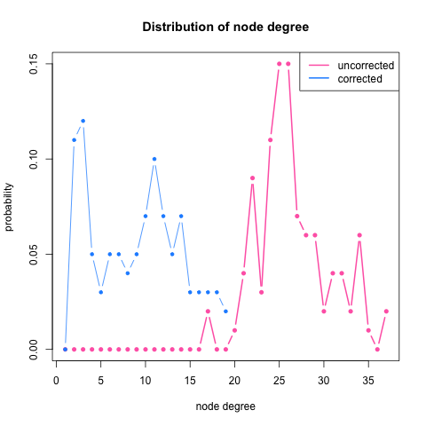

#### Diffusion Distance of $G(A)$ vs. $H(\tilde{A})$

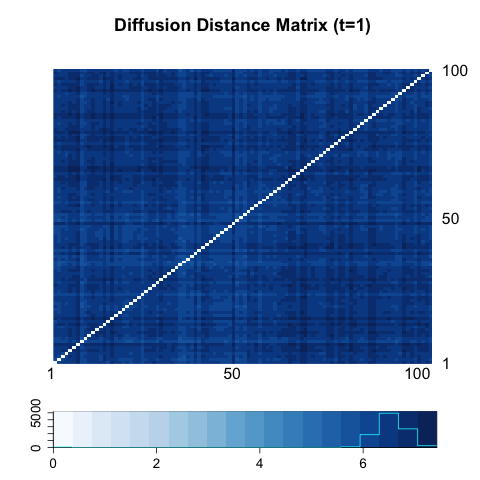

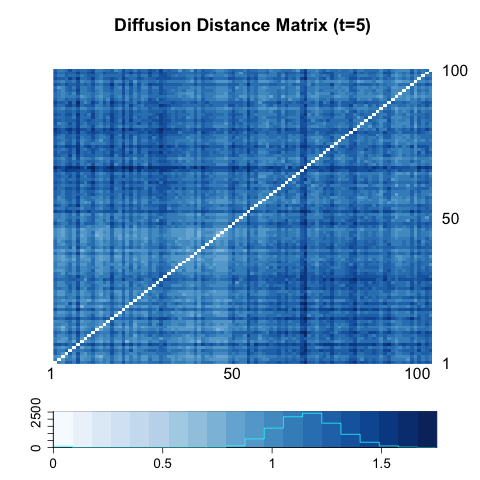

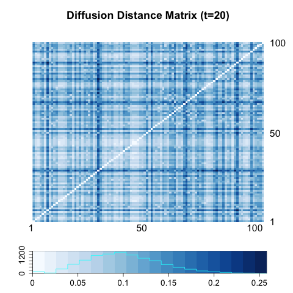

#### Power Heatmap of $G(A)$ vs. $H(\tilde{A})$

Optimal Power drops approximately from 60$\%$ to 30$\%$.

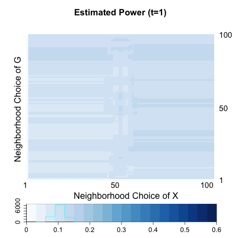

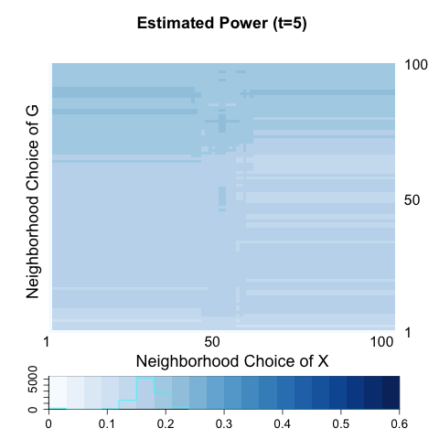

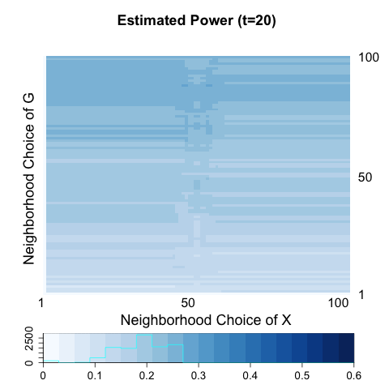

The plot of degree distribution tells us that using $\tilde{A}$ instead of $A$ does not give variability in vertex degree but just decreases the density of network at about 1/4.

[X Yan et al.](http://iopscience.iop.org/article/10.1088/1742-5468/2014/05/P05007/meta) suggest using another constraint in constructing CD-SBM. The likelihood hold stays the same if we increase $\theta_{i}$ by the same factor $c$ for all nodes in each block. In their paper, they put the constraint of $\sum\limits_{u : z_{u} = r} \theta_{u} = \sum\limits_{u : z_{u} = r} d_{u},$ which indicates that sum of $\theta_{u}$ within block is the total degree within each block. However, in this case the average number of edges increases as well as the variability of edge distributions increases.

I propose generating degree-corrected graph using $\theta_{i} \overset{i.i.d}{\sim} Unif(0 , 2)$, so that $E(\theta_{i} \theta_{j} a_{ij}) = E(\theta_{i})E(\theta_{j})E(a_{ij}) = E(a_{ij})$. Since $\theta_{i}$ could be greater than 1, it is also possible that $\theta_{i} \theta_{j} a_{ij} > 1$.

In Two Block 2, $\tilde{A}_{z_{i},z_{j}} \sim Bern \left( min(1, \theta_{z_{i}} \theta_{z_{j}} a(z_{i}, z_{j}) ) \right)$

In Two Block 3, $\tilde{A}_{z_{i},z_{j}} \sim Poisson \left( \theta_{z_{i}} \theta_{z_{j}} a(z_{i}, z_{j}) \right)$ and generate a weighted network. However, in transition matrix I use a binary adjacency matrix instead of taking into account edge weights.

## Two Block 2

$X_{i} \overset{i.i.d}{\sim} Bern(0.5), i = 1,... , 100$

$\theta_{i} \overset{i.i.d}{\sim} Unif(0 , \color{red}{2})$

$Z_{i} \sim \left\{ \begin{array}{cc} Bern(0.6) & X_{i} = 0 \\ Bern(0.4) & X_{i} = 1 \end{array} \right.$

$A_{z_{i}, z_{j}} \sim Bern \left[ \begin{array}{cc} \color{red}{0.4} & 0.1 \\ 0.1 & \color{red}{0.4} \end{array} \right]$

$\tilde{A}_{z_{i}, z_{j}} \sim Bern \left\{ min \left( \left[ \begin{array}{cc} \color{blue}{\theta_{z_{i}}\theta_{z_{j}} } \color{red}{0.4} & \color{blue}{\theta_{z_{i}}\theta_{z_{j}} }0.1 \\ \color{blue}{\theta_{z_{i}}\theta_{z_{j}} }0.1 & \color{blue}{\theta_{z_{i}}\theta_{z_{j}} } \color{red}{0.4} \end{array} \right] , \left[ \begin{array}{cc} 1 & 1 \\ 1 & 1 \end{array} \right] \right) \right\}$

#### Degree Distribution of $G(A)$ vs. $H(\tilde{A})$

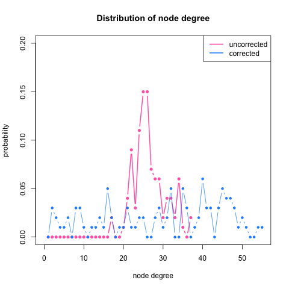

#### Diffusion Distance of $G(A)$ vs. $H(\tilde{A})$

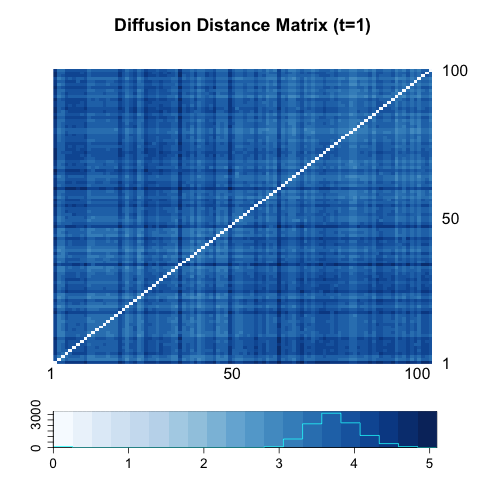

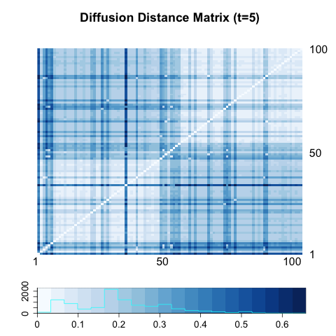

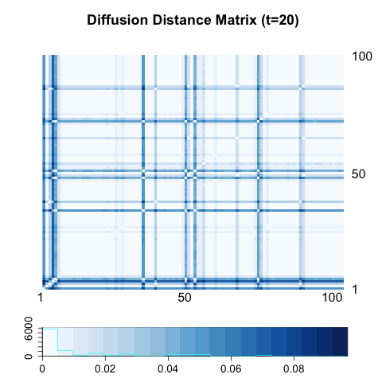

#### Power Heatmap of $G(A)$ vs. $H(\tilde{A})$

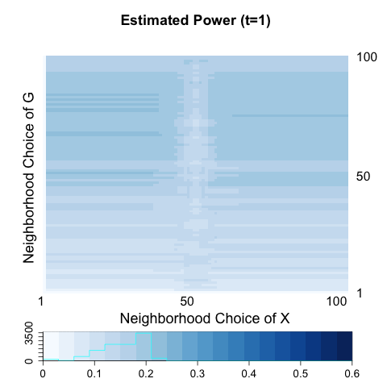

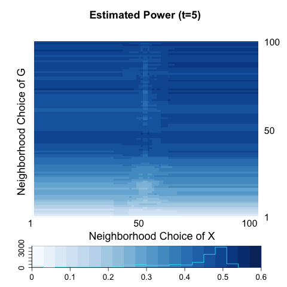

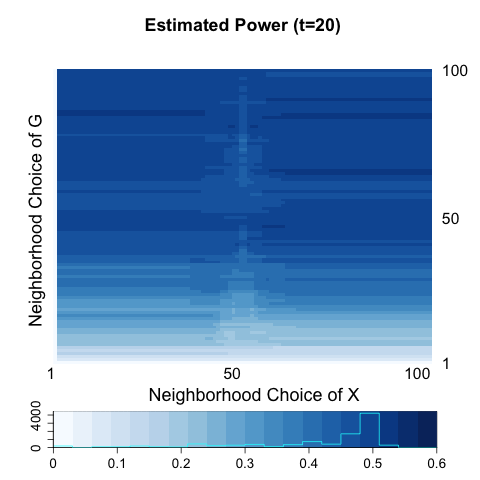

## Two Block 3

$X_{i} \overset{i.i.d}{\sim} Bern(0.5), i = 1,... , 100$

$\theta_{i} \overset{i.i.d}{\sim} Unif(0 , \color{red}{2})$

$Z_{i} \sim \left\{ \begin{array}{cc} Bern(0.6) & X_{i} = 0 \\ Bern(0.4) & X_{i} = 1 \end{array} \right.$

$A_{z_{i}, z_{j}} \sim Bern \left[ \begin{array}{cc} \color{red}{0.4} & 0.1 \\ 0.1 & \color{red}{0.4} \end{array} \right]$

$\tilde{A}_{z_{i}, z_{j}} \sim \color{red}{Poisson} \left[ \begin{array}{cc} \color{blue}{\theta_{z_{i}}\theta_{z_{j}} } \color{red}{0.4} & \color{blue}{\theta_{z_{i}}\theta_{z_{j}} }0.1 \\ \color{blue}{\theta_{z_{i}}\theta_{z_{j}} }0.1 & \color{blue}{\theta_{z_{i}}\theta_{z_{j}} } \color{red}{0.4} \end{array} \right]$

#### Degree Distribution of $G(A)$ vs. $H(\tilde{A})$

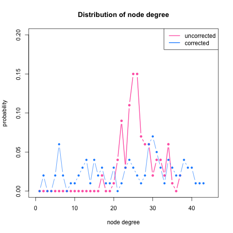

#### Diffusion Distance of $G(A)$ vs. $H(\tilde{A})$

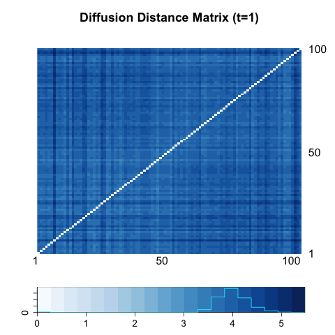

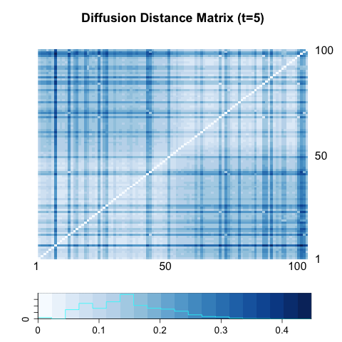

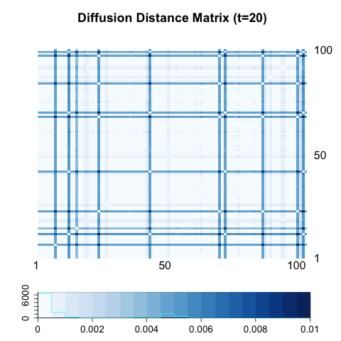

#### Power Heatmap of $G(A)$ vs. $H(\tilde{A})$

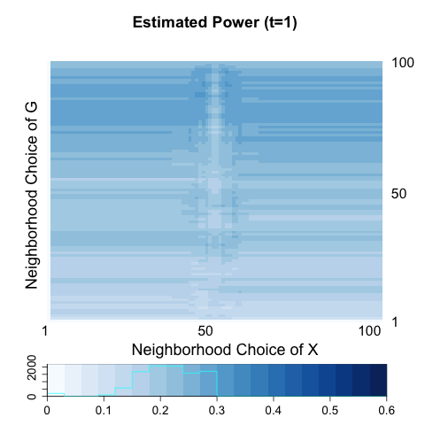

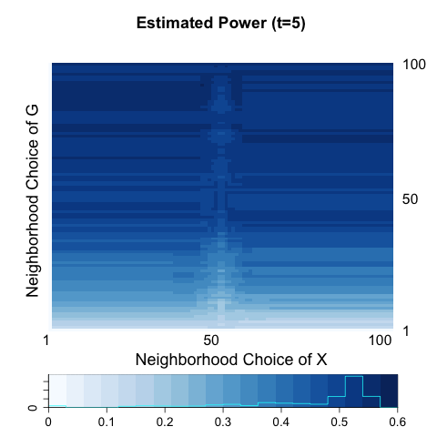

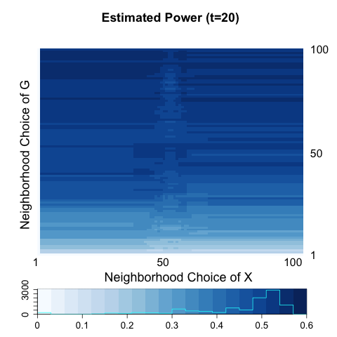

For both Two Block 2 and Two Block 3, averaged diffusion distance matrix over 100 independent networks lost distinct block patterns. This might be due to the increased variability between networks. Estimated power at t=1 for both cases, does not work as good as uncorrected SBM, but beyond diffusion time t=5, optimal power in corrected SBM works pretty well (about 5 $\%$ behind than uncorrected SBM).

## Three Block

$X_{i} \overset{i.i.d}{\sim} Multi(1/3, 1/3, 1/3), i = 1,..., 150$

$\theta_{i} \overset{i.i.d}{\sim} Unif(0 , \color{red}{2})$

$Z_{i} \overset{i.i.d}{\sim} \left\{ \begin{array}{cc} Multi(\color{red}{0.5}, 0.25, 0.25 ) & X_{i} = 1 \\ Multi(0.25, \color{red}{0.5}, 0.25 ) & X_{i} = 2 \\ Multi(0.25, 0.25, \color{red}{0.5} ) & X_{i} = 3 \end{array} \right.$

$A_{z_{i}, z_{j}} \sim Bern \left[ \begin{array}{cc} \color{red}{0.5} & 0.3 & 0.3 \\ 0.3 & \color{red}{0.5} & 0.3 \\ 0.3 & 0.3 & \color{red}{0.5} \end{array} \right]$

$\tilde{A}_{z_{i}, z_{j}} \sim Bern \left\{ min \left( \left[ \begin{array}{cc} \color{blue}{\theta_{z_{i}}\theta_{z_{j}} } \color{red}{0.5} & \color{blue}{\theta_{z_{i}}\theta_{z_{j}} }0.3 & \color{blue}{\theta_{z_{i}}\theta_{z_{j}} }0.3 \\ \color{blue}{\theta_{z_{i}}\theta_{z_{j}} }0.3 & \color{blue}{\theta_{z_{i}}\theta_{z_{j}} } \color{red}{0.5} & \color{blue}{\theta_{z_{i}}\theta_{z_{j}} }0.3 \\ \color{blue}{\theta_{z_{i}}\theta_{z_{j}} }0.3 & \color{blue}{\theta_{z_{i}}\theta_{z_{j}} }0.3 & \color{blue}{\theta_{z_{i}}\theta_{z_{j}} }\color{red}{0.5} \end{array} \right] , \left[ \begin{array}{cc} 1 & 1 & 1 \\ 1 & 1 & 1 \\ 1 & 1 & 1 \end{array} \right] \right) \right\}$

#### Degree Distribution of $G(A)$ vs. $H(\tilde{A})$

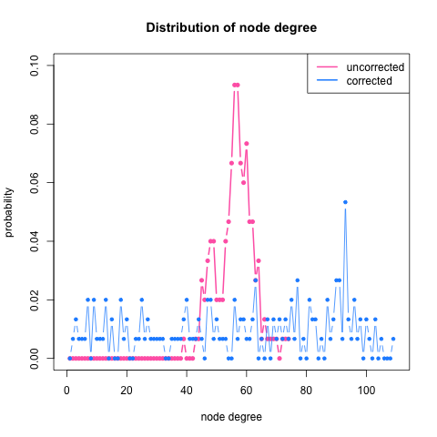

#### Diffusion Distance of $G(A)$ vs. $H(\tilde{A})$

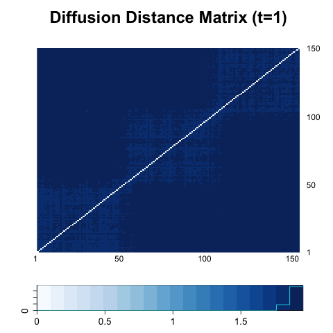

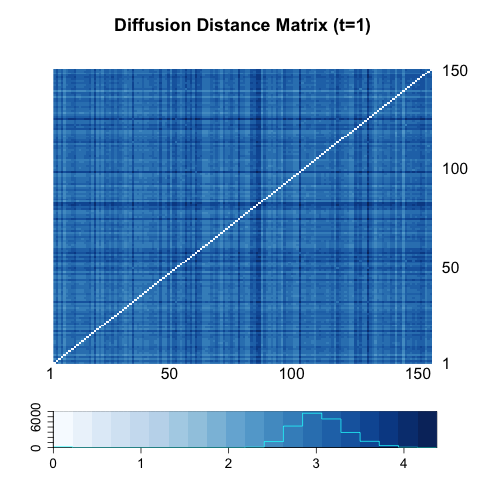

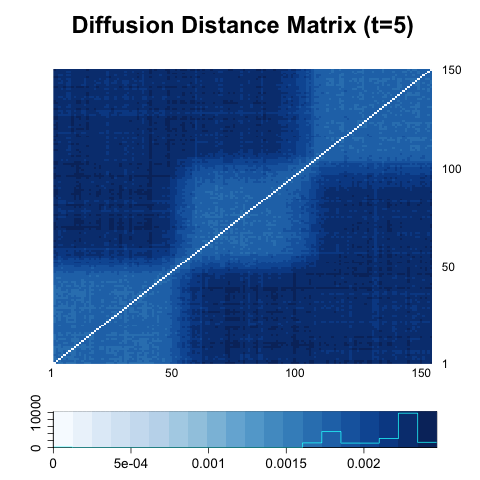

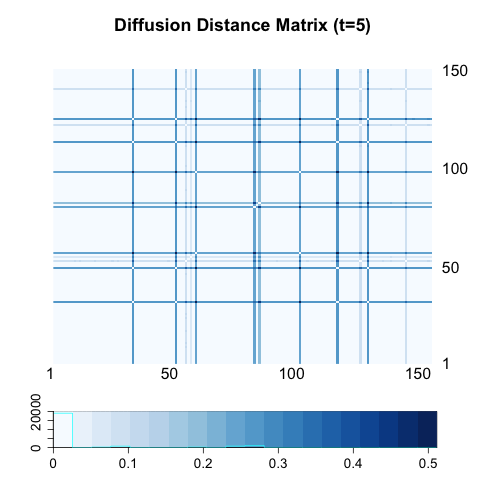

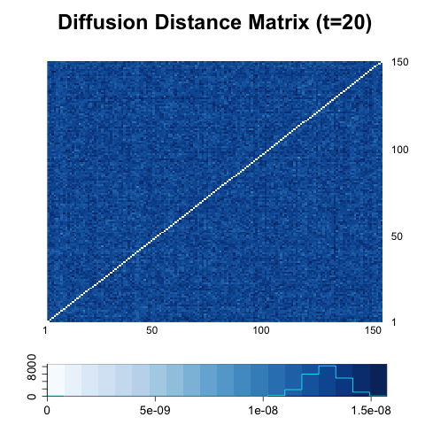

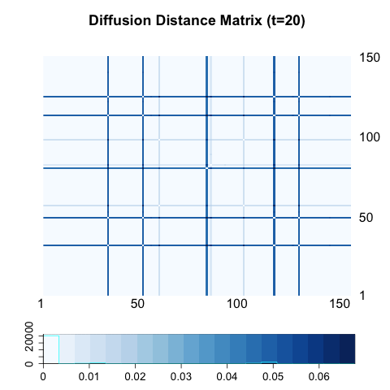